# *Workflow* de análisis de expresión diferencial usando RNA-seq

Mireia Ferrer, Ricardo Gonzalo y Alex Sanchez

Diciembre 2024

# 1 Reconocimiento y referencias

Este material se ha desarrollado a partir de distintas fuentes, basándose principalmente en las siguientes:

- [RNA-seq analysis in R. Differential expression analysis](http://combine-australia.github.io/RNAseq-R/06-rnaseq-day1.html)
- RNA-seq analysis is easy as 1-2-3 with limma, Glimma and edgeR
  - [Article](https://www.ncbi.nlm.nih.gov/pmc/articles/PMC4937821/)
  - [Bioconductor vignette](https://www.bioconductor.org/packages/release/workflows/vignettes/RNAseq123/inst/doc/limmaWorkflow.html)

El análisis que aquí se describe se puede encontrar llevado a cabo con *Galaxy* en una serie de tutoriales relacionados con el primero de los documentos:

- [1. RNASeq: Reads to counts](https://training.galaxyproject.org/archive/2021-08-01/topics/transcriptomics/tutorials/rna-seq-reads-to-counts/tutorial.html)
- [2. RNAseq: Counts to genes](https://training.galaxyproject.org/archive/2021-08-01/topics/transcriptomics/tutorials/rna-seq-counts-to-genes/tutorial.html)
- [3. RNASeq genes to pathways](https://training.galaxyproject.org/archive/2021-08-01/topics/transcriptomics/tutorials/rna-seq-genes-to-pathways/tutorial.html)

# 2 Antes de empezar

## 2.1 Directorios de trabajo

Cree un directorio para los datos llamado “data” donde colocar todos los archivos necesarios para los análisis.

Opcionalmente, puede crear un directorio “results” donde redirigir todos los archivos generados por los análisis.

Establezca el directorio de trabajo en la carpeta de donde cuelgan los datos o, **preferentemente**, cree un proyecto de Rstudio cuyo directorio principal sea dicha carpeta.

## 2.2 Instalación de paquetes

Para ejecutar este workflow se necesita tener instalado Bioconductor (tal como se indica en https://www.bioconductor.org/install/.

Además se utilizarán los siguientes paquetes: - Paquete `Rsubread`: proporciona herramientas para la alineación y cuantificación de lecturas. - Paquete `edgeR`: proporciona herramientas para pre-procesado, visualización y análisis de datos de contajes. - Paquete `limma`: proporciona herramientas para el análisis de expresión diferencial. - Paquete `pheatmap`: proporciona herramientas para trazar mapas de calor.

EL código siguiente los instalará si no están instalados y, en caso de que lo estén, los cargará en memoria (equivaliendo, en este caso, a una instrucción `library`).

En la práctica se puede ejecutar este código una vez y después comentarlo o ponerlo a FALSE en la cabecera del bloque de Rmarkdown.

```r
if (!require(Rsubread)) BiocManager::install("Rsubread")
if (!require(edgeR))BiocManager::install("edgeR")
if (!require(limma))BiocManager::install("limma")
if (!require(pheatmap))BiocManager::install("pheatmap")
if (!require(org.Mm.eg.db))BiocManager::install("org.Mm.db")
if (!require(clusterProfiler))BiocManager::install("clusterProfiler")
if (!require(factoextra)) install.packages("factoextra", dep=TRUE)
```

# 3 Datos para el análisis

## 3.1 *Dataset* de glándulas mamarias de ratón

Los datos para este tutorial provienen de un artículo de Nature Cell Biology, [EGF-mediated induction of Mcl-1 at the switch to lactation is essential for alveolar cell survival](https://pubmed.ncbi.nlm.nih.gov/25730472/) (Fu et al 2015).

Tanto los datos en bruto (lecturas de secuencia) como los datos procesados (recuentos) están disponibles para su descarga de la base de datos Gene Expression Omnibus (GEO) con el número de acceso GSE60450,: https://www.ncbi.nlm.nih.gov/geo/query/acc.cgi?acc=GSE60450.

Este estudio examina los perfiles de expresión de células madre basales enriquecidas (B) y células luminales comprometidas (L) en la glándula mamaria de ratones vírgenes, preñados y lactantes. El experimento se organizó en seis grupos, uno para cada combinación de tipo de célula y estado de ratón. Cada grupo contiene dos réplicas biológicas.

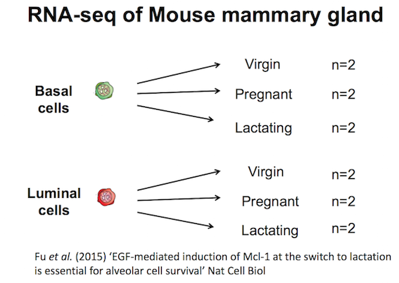

```r
knitr::include_graphics("images/mouse_exp.png")
```

## 3.2 Archivos

Para el análisis se dispone de los archivos siguientes, copiados en el directorio `data`:

- *SampleInfo.csv*: contiene información de ejemplo
- 4 archivos *.bam*: contienen los resultados de alineación para 4 de los ejemplos (“demo dataset”)
- *GSE60450_Lactation-GenewiseCounts.txt*: contiene la matriz de recuentos de todo el conjunto de datos.

### 3.2.1 Una aproximación opcional

El archivo `SampleInfo.csv` se ha creado específicamente para este análisis y el archivo de contajes se ha preparado a partir de los archivos comprimido con los archivos de contajes de cada muestra por separado disponible con el nombre `GSE60450_RAW.tar` en la página del estudio en GEO. Una alternativa para estos últimos podría haber sido utilizar el código siguiente para descargarlos a un directorio “download”.

```r
url <- "https://www.ncbi.nlm.nih.gov/geo/download/?acc=GSE60450&format=file"
utils::download.file(url, destfile="GSE60450_RAW.tar", mode="wb")
utils::untar("GSE60450_RAW.tar", exdir = "./download")
files <-paste("download",  dir("download"), sep="/")
for(i in files) R.utils::gunzip(i, overwrite=TRUE)
```

Una vez descargados se obtiene es un archivo de texto por cada muestra. Una posibilidad es leerlos por separado y combinarlos en una matriz de texto. En realidad esto no es preciso porque el archivo con los contajes de todas las muestras también se encuentra disponible, y descargable del mismo sitio:

```r
url <- "https://www.ncbi.nlm.nih.gov/geo/download/?acc=GSE60450&format=file&file=GSE60450%5FLactation%2DGenewiseCounts%2Etxt%2Egz"
utils::download.file(url, destfile="GSE60450_Lactation-GenewiseCounts.txt.gz", mode="wb")
R.utils::gunzip("GSE60450_Lactation-GenewiseCounts.txt.gz")
```

La función `readDGE` del paquete `edgeR` permite hacerlo directamente

```r
x <- readDGE(files, columns=c(1,3))
class(x)
slotNames(x)
class(x@.Data)
lapply(x@.Data, dim)
```

Proceder así evitaría tener que descargar manualmente los archivos. En lo que sigue asumiremos que se han descargado y almacenado tal como se indica en el apartado anterior.

## 3.3 Creación de la información de entrada

El archivo *SampleInfo.csv* contiene información básica acerca de los archivos, definición de los grupos, covariables y otra información de utilidad.

```r
# Read the sample information into R
sampleinfo <- read.delim("./data/SampleInfo.txt", head=TRUE, sep="\t")
sampleinfo
```

```
##                             FileName SampleName ShortName CellType   Status
## 1  MCL1.DG_BC2CTUACXX_ACTTGA_L002_R1    MCL1.DG BASVIR.DG    basal   virgin
## 2  MCL1.DH_BC2CTUACXX_CAGATC_L002_R1    MCL1.DH BASVIR.DH    basal   virgin
## 3  MCL1.DI_BC2CTUACXX_ACAGTG_L002_R1    MCL1.DI BASPRE.DI    basal pregnant
## 4  MCL1.DJ_BC2CTUACXX_CGATGT_L002_R1    MCL1.DJ BASPRE.DJ    basal pregnant
## 5  MCL1.DK_BC2CTUACXX_TTAGGC_L002_R1    MCL1.DK BASLAC.DK    basal  lactate
## 6  MCL1.DL_BC2CTUACXX_ATCACG_L002_R1    MCL1.DL BASLAC.DL    basal  lactate
## 7  MCL1.LA_BC2CTUACXX_GATCAG_L001_R1    MCL1.LA LUMVIR.LA  luminal   virgin
## 8  MCL1.LB_BC2CTUACXX_TGACCA_L001_R1    MCL1.LB LUMVIR.LB  luminal   virgin
## 9  MCL1.LC_BC2CTUACXX_GCCAAT_L001_R1    MCL1.LC LUMPRE.LC  luminal pregnant
## 10 MCL1.LD_BC2CTUACXX_GGCTAC_L001_R1    MCL1.LD LUMPRE.LD  luminal pregnant
## 11 MCL1.LE_BC2CTUACXX_TAGCTT_L001_R1    MCL1.LE LUMLAC.LE  luminal  lactate
## 12 MCL1.LF_BC2CTUACXX_CTTGTA_L001_R1    MCL1.LF LUMLAC.LF  luminal  lactate
##            SRAFileName
## 1  SRR1552450.fastq.gz
## 2  SRR1552451.fastq.gz
## 3  SRR1552452.fastq.gz
## 4  SRR1552453.fastq.gz
## 5  SRR1552454.fastq.gz
## 6  SRR1552455.fastq.gz
## 7  SRR1552444.fastq.gz
## 8  SRR1552445.fastq.gz
## 9  SRR1552446.fastq.gz
## 10 SRR1552447.fastq.gz
## 11 SRR1552448.fastq.gz
## 12 SRR1552449.fastq.gz
```

Obsérvese que la columna “SRAFileName” nos indica los archivos FastQ originales con *todos* las lecturas, que podríamos descargar de la base de datos SRA de NCBI. Puesto que estos archivos ocupan mas de 20 Gb en el apartado siguiente se ilustra como se procedería usando un subconjunto de los mismos.

# 4 Obtención de la matriz de recuentos

## 4.1 Cuantificación de lecturas alineadas

La alineación de lecturas, obtenidas al secuenciar, con el genoma de referencia, produce un conjunto de archivos BAM, donde cada archivo contiene las secuencias alineadas de cada librería.

Puesto que este proceso es computacionalmente intensivo se muestra como hacerlo utilizando un subconjunto de 1000 lecturas por muestra, alineadas únicamente con el cromosoma 1 del genoma del ratón.

Utilizaremos el paquete `Rsubread`, que proporciona funciones para alineamiento y cuantificación de lecturas.

```r
library(Rsubread)
bam.files <- list.files(path = "./data", pattern = ".BAM$", full.names = TRUE)
bam.files
```

```
## [1] "./data/SRR1552444.fastq.gz.subread.BAM"
## [2] "./data/SRR1552445.fastq.gz.subread.BAM"
## [3] "./data/SRR1552446.fastq.gz.subread.BAM"
## [4] "./data/SRR1552447.fastq.gz.subread.BAM"
```

Las funciones del paquete nos permiten ver, por ejemplo, la proporción de lecturas alineadas con los genes del cromosoma 1:

```r
props <- propmapped(files=bam.files)[,1:2]
props
```

```
##                                 NumTotal NumMapped
## SRR1552444.fastq.gz.subread.BAM     1000       145
## SRR1552445.fastq.gz.subread.BAM     1000       136
## SRR1552446.fastq.gz.subread.BAM     1000       120
## SRR1552447.fastq.gz.subread.BAM     1000       113
```

Las lecturas alineadas se pueden contar a través de cada gen mediante la función `featureCounts`. Esta función incorpora anotaciones integradas para ensamblajes del genoma de ratón (mm9, mm10) y humano (hg19) (anotación REFSEQ NCBI).

El siguiente código utiliza los exones definidos en la anotación `refseq ncbi` del genoma `mm10`. Las lecturas mapeados en exones se suman para obtener el recuento de cada gen con tratamiento especial para aquellas que abarcan los límites exón-exón.

`featureCounts` toma todos los archivos BAM como entrada y devuelve un objeto que incluye la matriz de contajes. Cada muestra da lugar a una columna y cada fila corresponde con los recuentos acumulados para un gen, en dicha muestra.

```r
fc <- featureCounts(bam.files, annot.inbuilt="mm10")
```

[output not shown]

[output cut: 11 more lines]

[output not shown]

```r
class(fc)
```

```
## [1] "list"
```

```r
names(fc)
```

```
## [1] "counts"     "annotation" "targets"    "stat"
```

El objeto resultante es una lista. Observando los componentes que contiene puede observarse que podría haberse utilizado un `expressionSet` (o crear una nueva clase a partir de ésta) para contener los resultados, aunque, aparentemente, los desarrolladores han preferido no hacerlo.

Las estadísticas del mapeo leído se pueden ver con `fc$stats`. Esto informa el número de “reads” no asignadas y las razones por las que no se asignan (por ejemplo, ambigüedad, multimapeo,…), además del número de “reads” asignadas correctamente para cada librería. (Sabemos la verdadera razón por la que la mayoría de las lecturas no se han mapeado correctamente y es que no son del cromosoma 1!)

```r
## Take a look at the featurecounts stats
fc$stat
```

```
##                           Status SRR1552444.fastq.gz.subread.BAM
## 1                       Assigned                              50
## 2            Unassigned_Unmapped                             855
## 3           Unassigned_Read_Type                               0
## 4           Unassigned_Singleton                               0
## 5      Unassigned_MappingQuality                               0
## 6             Unassigned_Chimera                               0
## 7      Unassigned_FragmentLength                               0
## 8           Unassigned_Duplicate                               0
## 9        Unassigned_MultiMapping                               0
## 10          Unassigned_Secondary                               0
## 11           Unassigned_NonSplit                               0
## 12         Unassigned_NoFeatures                              95
## 13 Unassigned_Overlapping_Length                               0
## 14          Unassigned_Ambiguity                               0
```

[output cut: 30 more lines]

Las anotaciones contienen la información de los “reads” que se han colapsado (combinado) en cada gen:

```r
head(fc$annotation)
```

```
##      GeneID                           Chr
## 1    497097                chr1;chr1;chr1
## 2 100503874                     chr1;chr1
## 3 100038431                          chr1
## 4     19888 chr1;chr1;chr1;chr1;chr1;chr1
## 5     20671      chr1;chr1;chr1;chr1;chr1
## 6     27395      chr1;chr1;chr1;chr1;chr1
##                                             Start
## 1                         3214482;3421702;3670552
## 2                                 3647309;3658847
## 3                                         3680155
## 4 4290846;4343507;4351910;4352202;4360200;4409170
## 5         4490928;4493100;4493772;4495136;4496291
## 6         4773198;4777525;4782568;4783951;4785573
##                                               End      Strand Length
## 1                         3216968;3421901;3671498       -;-;-   3634
## 2                                 3650509;3658904         -;-   3259
## 3                                         3681788           +   1634
## 4 4293012;4350091;4352081;4352837;4360314;4409241 -;-;-;-;-;-   9747
## 5         4492668;4493466;4493863;4495942;4496413   -;-;-;-;-   3130
## 6         4776801;4777648;4782733;4784105;4785726   -;-;-;-;-   4203
```

La información de cada muestra en cada gen se guarda finalmente en `fc$counts` cuyas dimensiones nos informan tanto de las muestras como de los genes.

```r
dim(fc$counts)
```

```
## [1] 27179     4
```

```r
head(fc$counts)
```

```
##           SRR1552444.fastq.gz.subread.BAM SRR1552445.fastq.gz.subread.BAM
## 497097                                  0                               0
## 100503874                               0                               0
## 100038431                               0                               0
## 19888                                   0                               0
## 20671                                   0                               0
## 27395                                   0                               0
##           SRR1552446.fastq.gz.subread.BAM SRR1552447.fastq.gz.subread.BAM
## 497097                                  0                               0
## 100503874                               0                               0
## 100038431                               0                               0
## 19888                                   0                               0
## 20671                                   0                               0
## 27395                                   0                               0
```

```r
counts_chr1 <- fc$counts
```

En este caso guardaremos la matriz de contajes para su uso posterior

```r
write.table(counts_chr1, "data/counts_chr1.txt")
```

### 4.1.1 Ejercicio

- Repetir el recuento sobre los exones, en lugar de los genes (especifique `useMetaFeatures = FALSE`), y llame al objeto `featureCounts fc.exon`.
- Compruebe la dimensión de la matriz de recuentos. ¿Observa alguna diferencia?

## 4.2 Importación de una matriz

Como se ha comentado en la sección anterior, la matriz de recuento original (de todo el conjunto de datos) generada en el estudio se ha descargado del sitio web de GEO [GEO website](http://www.ncbi.nlm.nih.gov/geo/query/acc.cgi?acc=GSE60450) y está contenida en el archivo `GSE60450_Lactation-GenewiseCounts.txt`.

- Echemos un vistazo a los datos.

```r
seqdata <- read.delim("./data/GSE60450_Lactation-GenewiseCounts.txt", stringsAsFactors = FALSE)
dim(seqdata)
```

```
## [1] 27179    14
```

```r
head(seqdata)
```

```
##   EntrezGeneID Length MCL1.DG_BC2CTUACXX_ACTTGA_L002_R1
## 1       497097   3634                               438
## 2    100503874   3259                                 1
## 3    100038431   1634                                 0
## 4        19888   9747                                 1
## 5        20671   3130                               106
## 6        27395   4203                               309
##   MCL1.DH_BC2CTUACXX_CAGATC_L002_R1 MCL1.DI_BC2CTUACXX_ACAGTG_L002_R1
## 1                               300                                65
## 2                                 0                                 1
## 3                                 0                                 0
## 4                                 1                                 0
## 5                               182                                82
## 6                               234                               337
##   MCL1.DJ_BC2CTUACXX_CGATGT_L002_R1 MCL1.DK_BC2CTUACXX_TTAGGC_L002_R1
```

[output cut: 34 more lines]

El objeto `seqdata` contiene información sobre genes (un gen por fila). La primera columna tiene el identificador `Entrez`, la segunda tiene la longitud del gen y las columnas restantes contienen información sobre el número de “reads” alineadas con el gen en cada muestra experimental.

Manipularemos y re-formatearemos la matriz de recuentos en un formato adecuado para el análisis posterior. Necesitamos hacer una nueva matriz que contenga únicamente los recuentos, pero podemos almacenar los identificadores de genes (la columna `EntrezGeneID`) como nombres de fila (obsérvese que esto podrá hacerse así porque estos identificadores son únicos, puesto que no trabajamos con transcritos sino con genes, que tienen identificadores únicos).

El nuevo objeto `countdata`, contiene únicamente los contajes para las 12 muestras

```r
countdata <- seqdata[,-(1:2)]
rownames(countdata) <- seqdata$EntrezGeneID
```

Si nos fijamos en los nombres de las columnas vemos que son los nombres de archivo para cada muestra, que son bastante largos. Cambiaremos el nombre de las columnas con los `sampleNames` almacenados en el `data.frame` `sampleinfo`.

```r
colnames(countdata)
```

```
##  [1] "MCL1.DG_BC2CTUACXX_ACTTGA_L002_R1" "MCL1.DH_BC2CTUACXX_CAGATC_L002_R1"
##  [3] "MCL1.DI_BC2CTUACXX_ACAGTG_L002_R1" "MCL1.DJ_BC2CTUACXX_CGATGT_L002_R1"
##  [5] "MCL1.DK_BC2CTUACXX_TTAGGC_L002_R1" "MCL1.DL_BC2CTUACXX_ATCACG_L002_R1"
##  [7] "MCL1.LA_BC2CTUACXX_GATCAG_L001_R1" "MCL1.LB_BC2CTUACXX_TGACCA_L001_R1"
##  [9] "MCL1.LC_BC2CTUACXX_GCCAAT_L001_R1" "MCL1.LD_BC2CTUACXX_GGCTAC_L001_R1"
## [11] "MCL1.LE_BC2CTUACXX_TAGCTT_L001_R1" "MCL1.LF_BC2CTUACXX_CTTGTA_L001_R1"
```

Primero debemos verificar que estén en el mismo orden (¡esto es muy importante!):

```r
all.equal(colnames(countdata), sampleinfo$FileName)
```

```
## [1] TRUE
```

Una vez confirmado podemos asignar los nuevos nombres:

```r
colnames(countdata) <- sampleinfo$ShortName
head(countdata)
```

```
##           BASVIR.DG BASVIR.DH BASPRE.DI BASPRE.DJ BASLAC.DK BASLAC.DL LUMVIR.LA
## 497097          438       300        65       237       354       287         0
## 100503874         1         0         1         1         0         4         0
## 100038431         0         0         0         0         0         0         0
## 19888             1         1         0         0         0         0        10
## 20671           106       182        82       105        43        82        16
## 27395           309       234       337       300       290       270       560
##           LUMVIR.LB LUMPRE.LC LUMPRE.LD LUMLAC.LE LUMLAC.LF
## 497097            0         0         0         0         0
## 100503874         0         0         0         0         0
## 100038431         0         0         0         0         0
## 19888             3        10         2         0         0
## 20671            25        18         8         3        10
## 27395           464       489       328       307       342
```

# 5 Preprocesado de los datos

## 5.1 Filtraje de genes poco expresados

Los genes con recuentos muy bajos en todas las librerías proporcionan poca evidencia de expresión diferencial e interfieren con algunas de las aproximaciones estadísticas que se utilizarán más adelante. Además penalizan los ajustes por comparaciones múltiples para estimar las tasas de falsos positivos, lo que resta potencia para detectar genes expresados diferencialmente. Por este motivo, se aconseja filtrar estos genes antes de continuar los análisis.

Antes de filtrar, sin embargo, expresaremos los contajes en “CPMs” es decir “counts per million” con el fin de evitar que se atribuyan valores demasiado bajos debido a tamaños distintos de las librerías.

Es decir, en primer lugar se estandarizan los contajes basándonos en el tamaño de la librería y a continuación se realizará el filtraje.

Para ello se normalizaran los contajes brutos para las diferentes profundidades de secuenciación (tamaños de librería) para cada muestra y se compararan con los valores de recuento por millón (CPM) utilizando la función `cpm()` del paquete `edgeR`.

En nuestro caso elegimos retener aquellos genes que *se expresan a un CPM superior a 0,5 en al menos dos muestras*. Esto es obviamente arbitrario, pero la experiencia sugiere que cantidades inferiores a éstas, u otras similares, suelen corresponderse con ausencia de expresión, más que otra explicación.

Los tamaños de las librerías se obtienen simplemente sumando las columnas de la matriz de datos, aunque no hace falta que ésto se lleve a cabo explícitamente puesto que la función `cpm` lo hace de forma automática.

```r
colSums(countdata)
```

```
## BASVIR.DG BASVIR.DH BASPRE.DI BASPRE.DJ BASLAC.DK BASLAC.DL LUMVIR.LA LUMVIR.LB
##  23227641  21777891  24100765  22665371  21529331  20015386  20392113  21708152
## LUMPRE.LC LUMPRE.LD LUMLAC.LE LUMLAC.LF
##  22241607  21988240  24723827  24657293
```

```r
library(edgeR)
counts.CPM <- cpm(countdata)
head(counts.CPM)
```

```
##             BASVIR.DG   BASVIR.DH   BASPRE.DI   BASPRE.DJ BASLAC.DK  BASLAC.DL
## 497097    18.85684388 13.77543859  2.69700983 10.45648006 16.442685 14.3389690
## 100503874  0.04305215  0.00000000  0.04149246  0.04412017  0.000000  0.1998463
## 100038431  0.00000000  0.00000000  0.00000000  0.00000000  0.000000  0.0000000
## 19888      0.04305215  0.04591813  0.00000000  0.00000000  0.000000  0.0000000
## 20671      4.56352843  8.35709941  3.40238163  4.63261775  1.997275  4.0968483
## 27395     13.30311589 10.74484210 13.98295863 13.23605071 13.469996 13.4896224
##            LUMVIR.LA  LUMVIR.LB  LUMPRE.LC   LUMPRE.LD  LUMLAC.LE  LUMLAC.LF
## 497097     0.0000000  0.0000000  0.0000000  0.00000000  0.0000000  0.0000000
## 100503874  0.0000000  0.0000000  0.0000000  0.00000000  0.0000000  0.0000000
## 100038431  0.0000000  0.0000000  0.0000000  0.00000000  0.0000000  0.0000000
## 19888      0.4903857  0.1381969  0.4496078  0.09095771  0.0000000  0.0000000
## 20671      0.7846171  1.1516411  0.8092940  0.36383085  0.1213404  0.4055595
## 27395     27.4615975 21.3744588 21.9858214 14.91706476 12.4171715 13.8701357
```

Una vez obtenidos los CPMS se calcula el umbral de corte y éste se utiliza para generar una matriz booleana que se utilizará para el filtraje

```r
# Que valores son superiores a 0.5?
thresh <- counts.CPM > 0.5
# El resultado es una matriz booleanacon valores TRUEs y FALSE
head(thresh)
```

```
##           BASVIR.DG BASVIR.DH BASPRE.DI BASPRE.DJ BASLAC.DK BASLAC.DL LUMVIR.LA
## 497097         TRUE      TRUE      TRUE      TRUE      TRUE      TRUE     FALSE
## 100503874     FALSE     FALSE     FALSE     FALSE     FALSE     FALSE     FALSE
## 100038431     FALSE     FALSE     FALSE     FALSE     FALSE     FALSE     FALSE
## 19888         FALSE     FALSE     FALSE     FALSE     FALSE     FALSE     FALSE
## 20671          TRUE      TRUE      TRUE      TRUE      TRUE      TRUE      TRUE
## 27395          TRUE      TRUE      TRUE      TRUE      TRUE      TRUE      TRUE
##           LUMVIR.LB LUMPRE.LC LUMPRE.LD LUMLAC.LE LUMLAC.LF
## 497097        FALSE     FALSE     FALSE     FALSE     FALSE
## 100503874     FALSE     FALSE     FALSE     FALSE     FALSE
## 100038431     FALSE     FALSE     FALSE     FALSE     FALSE
## 19888         FALSE     FALSE     FALSE     FALSE     FALSE
## 20671          TRUE      TRUE     FALSE     FALSE     FALSE
## 27395          TRUE      TRUE      TRUE      TRUE      TRUE
```

```r
# we would like to keep genes that have at least 2 TRUES in each row of thresh
keep <- rowSums(thresh) >= 2
# Subset the rows of countdata to keep the more highly expressed genes
counts.keep <- countdata[keep,]
dim(countdata)
```

```
## [1] 27179    12
```

```r
dim(counts.keep)
```

```
## [1] 15804    12
```

## 5.2 Uso de clases específicas para manejar los datos

La primera parte del pre-procesado se ha llevado a cabo sin utilizar ni funciones ni clases específicas, como podría ser `expressionSet,`summarizedExperiment`para los datos o alguna variante de`nsFilter` para el filtraje.

Si bien esto puede ser útil con finalidades didácticas, siempre es más eficiente trabajar con clases creadas específicamente para gestionar tipos de datos complejos como las citadas, o, en este caso la clase `DGEList`, una clase S4, definida en el paquete `edgeR` que utiliza listas para almacenar recuentos de “reads” e información asociada de tecnologías de secuenciación o expresión génica digital.

```r
dgeObj <- DGEList(counts.keep)
# have a look at dgeObj
dgeObj
```

```
## An object of class "DGEList"
## $counts
##        BASVIR.DG BASVIR.DH BASPRE.DI BASPRE.DJ BASLAC.DK BASLAC.DL LUMVIR.LA
## 497097       438       300        65       237       354       287         0
## 20671        106       182        82       105        43        82        16
## 27395        309       234       337       300       290       270       560
## 18777        652       515       948       935       928       791       826
## 21399       1604      1495      1721      1317      1159      1066      1334
##        LUMVIR.LB LUMPRE.LC LUMPRE.LD LUMLAC.LE LUMLAC.LF
## 497097         0         0         0         0         0
## 20671         25        18         8         3        10
## 27395        464       489       328       307       342
## 18777        862       668       646       544       581
## 21399       1258      1068       926       508       500
## 15799 more rows ...
##
## $samples
##           group lib.size norm.factors
## BASVIR.DG     1 23218026            1
## BASVIR.DH     1 21768136            1
## BASPRE.DI     1 24091588            1
## BASPRE.DJ     1 22656713            1
## BASLAC.DK     1 21522033            1
## 7 more rows ...
```

```r
# See what slots are stored in dgeObj
names(dgeObj)
```

```
## [1] "counts"  "samples"
```

```r
# Library size information is stored in the samples slot
dgeObj$samples
```

```
##           group lib.size norm.factors
## BASVIR.DG     1 23218026            1
## BASVIR.DH     1 21768136            1
## BASPRE.DI     1 24091588            1
## BASPRE.DJ     1 22656713            1
## BASLAC.DK     1 21522033            1
## BASLAC.DL     1 20008326            1
## LUMVIR.LA     1 20384562            1
## LUMVIR.LB     1 21698793            1
## LUMPRE.LC     1 22235847            1
## LUMPRE.LD     1 21982745            1
## LUMLAC.LE     1 24719697            1
## LUMLAC.LF     1 24652963            1
```

# 6 Exploración de los datos

Una vez descartados los genes poco expresados y con los recuentos almacenados en un objeto `DGEList`, podemos`proceder a realizar algunos gráficos exploratorios para determinar si los datos aparentan buena calidad y/o si presentan algún problema.

## 6.1 Boxplot de los recuentos no normalizados

Los datos de contajes no se distribuyen normalmente, por lo que si queremos examinar las distribuciones de los recuentos sin procesar, debemos transformarlos, por ejemplo tomando logaritmos (la transformación habitual para contajes).

Podemos usar la función `cpm` para obtener recuentos `log2` por millón, que se corrigen para los diferentes tamaños de biblioteca. La función `cpm` también agrega una pequeña cantidad evitar tomar log de cero.

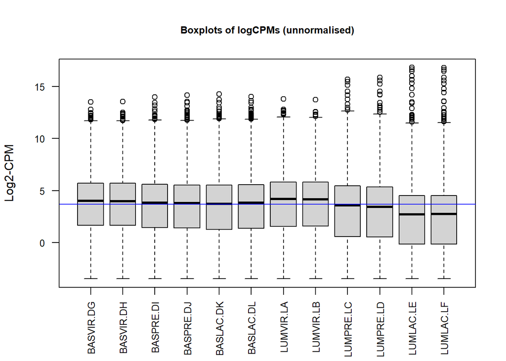

```r
# Get log2 counts per million
logcounts <- cpm(dgeObj,log=TRUE)
# Check distributions of samples using boxplots
boxplot(logcounts, ylab="Log2-CPM",las=2, xlab="", cex.axis=0.8, main="Boxplots of logCPMs (unnormalised)", cex.main=0.8)
# Let's add a blue horizontal line that corresponds to the median logCPM
abline(h=median(logcounts), col="blue")
```

A partir de los boxplots vemos que, en general, las distribuciones de densidad de las intensidades logarítmicas brutas no son idénticas, pero tampoco muy diferentes. Si una muestra está realmente muy por encima o por debajo de la línea horizontal azul, es posible que tengamos que investigar esa muestra más a fondo.

## 6.2 Normalización

La normalización TMM se realiza para eliminar los sesgos de composición entre librerías (Mark D. Robinson y Oshlack 2010). Esto genera un conjunto de factores de normalización, donde el producto de estos factores y los tamaños de librería definen el tamaño efectivo de la biblioteca. La función `calcNormFactors` calcula los factores de normalización entre librerías.

```r
# Apply normalisation to DGEList object
dgeObj_norm <- calcNormFactors(dgeObj)
```

Esto actualizará los factores de normalización en el objeto DGEList (sus valores predeterminados son 1).

```r
dgeObj_norm
```

```
## An object of class "DGEList"
## $counts
##        BASVIR.DG BASVIR.DH BASPRE.DI BASPRE.DJ BASLAC.DK BASLAC.DL LUMVIR.LA
## 497097       438       300        65       237       354       287         0
## 20671        106       182        82       105        43        82        16
## 27395        309       234       337       300       290       270       560
## 18777        652       515       948       935       928       791       826
## 21399       1604      1495      1721      1317      1159      1066      1334
##        LUMVIR.LB LUMPRE.LC LUMPRE.LD LUMLAC.LE LUMLAC.LF
## 497097         0         0         0         0         0
## 20671         25        18         8         3        10
## 27395        464       489       328       307       342
## 18777        862       668       646       544       581
## 21399       1258      1068       926       508       500
## 15799 more rows ...
##
## $samples
##           group lib.size norm.factors
## BASVIR.DG     1 23218026     1.236899
## BASVIR.DH     1 21768136     1.213949
## BASPRE.DI     1 24091588     1.125564
## BASPRE.DJ     1 22656713     1.069826
## BASLAC.DK     1 21522033     1.035921
## 7 more rows ...
```

Si ahora repetimos el gráfico con los contajes normalizados veremos como las diferencias se han reducido haciendo los datos *más comparables* que es lo que se persigue.

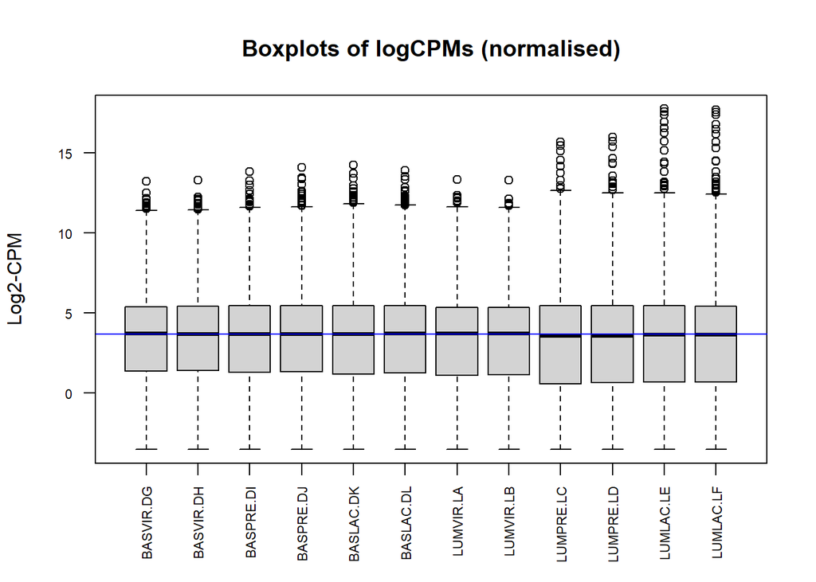

```r
# Get log2 counts per million
logcounts_norm <- cpm(dgeObj_norm,log=TRUE)
# Check distributions of samples using boxplots
boxplot(logcounts_norm, ylab="Log2-CPM",las=2, xlab="", cex.axis=0.7, main="Boxplots of logCPMs (normalised)")
# Let's add a blue horizontal line that corresponds to the median logCPM
abline(h=median(logcounts_norm), col="blue")
```

## 6.3 Análisis no supervisado de similaridad entre las muestras

En general, en un estudio experimental en donde buscamos comparar distintas condiciones o tratamientos, esperaremos que las muestras pertenecientes al mismo grupo *se parezcan* más entre ellas que a las de los otros grupos.

Esta idea intuitiva puede concretarse a través de calcular y visualizar de alguna forma la similaridad entre las muestras. Esto puede hacerse de distintas formas pero algunas de las más habituales son, el *cluster* o agrupamiento jerárquico y los métodos de reducción de la dimensión como el análisis de componentes principales (PCA) o el escalamiento multidimensional (MDS). Éste último tiene la ventaja que permite visualizar en dimensión reducida las similaridades entre muestras, más que los datos directos que es lo que hace el PCA.

La función `dist` permite calcular una *matriz de distancias* que contiene las comparaciones dos a dos entre todas las muestras.

```r
sampleDists <- dist(t(logcounts_norm))
sampleDists
```

```
##           BASVIR.DG BASVIR.DH BASPRE.DI BASPRE.DJ BASLAC.DK BASLAC.DL LUMVIR.LA
## BASVIR.DH  52.24654
## BASPRE.DI 103.25705  98.25760
## BASPRE.DJ 106.36290  99.30647  49.57083
## BASLAC.DK 128.02782 128.52821  97.62799  84.98948
## BASLAC.DL 125.86559 128.72828 103.11545  91.44977  46.73993
## LUMVIR.LA 218.22594 223.31947 232.50124 240.44598 256.64000 255.82355
## LUMVIR.LB 213.88210 217.09336 227.33020 234.98455 252.24239 251.40030  49.09938
## LUMPRE.LC 254.83729 258.89974 248.39509 260.65913 278.07560 278.52744 149.14326
## LUMPRE.LD 256.73737 260.11015 250.41689 260.28317 276.28758 276.87809 151.29250
## LUMLAC.LE 286.34996 290.39742 281.73902 291.20531 300.88662 300.60275 190.63664
## LUMLAC.LF 286.33309 290.93812 282.03286 291.46680 300.33939 299.46065 194.42521
##           LUMVIR.LB LUMPRE.LC LUMPRE.LD LUMLAC.LE
## BASVIR.DH
## BASPRE.DI
## BASPRE.DJ
## BASLAC.DK
## BASLAC.DL
## LUMVIR.LA
## LUMVIR.LB
## LUMPRE.LC 147.62266
## LUMPRE.LD 149.31188  59.52261
## LUMLAC.LE 190.51543 135.82290 136.62798
## LUMLAC.LF 193.93716 140.07902 141.13206  60.82715
```

Las matrices de distancias se pueden visualizar directamente mediante un heatmap, que nos dará una idea de si hay alguna muestra que discrepe de las demás o no se agrupe “como sería de esperar” (las comillas indican que no siempre se sabe qué esperar).

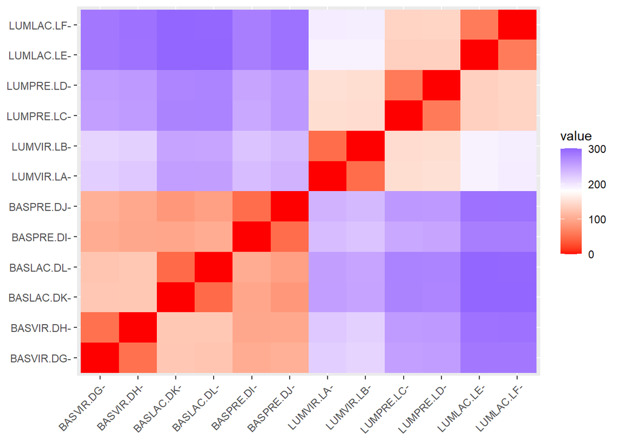

```r
library(factoextra)
fviz_dist(sampleDists)
```

A partir de la matriz de distancias podemos realizar un agrupamiento jerárquico de las muestras en donde se puede ver como éstas tienden a agruparse de forma natural por los grupos experimentales que se han definido.

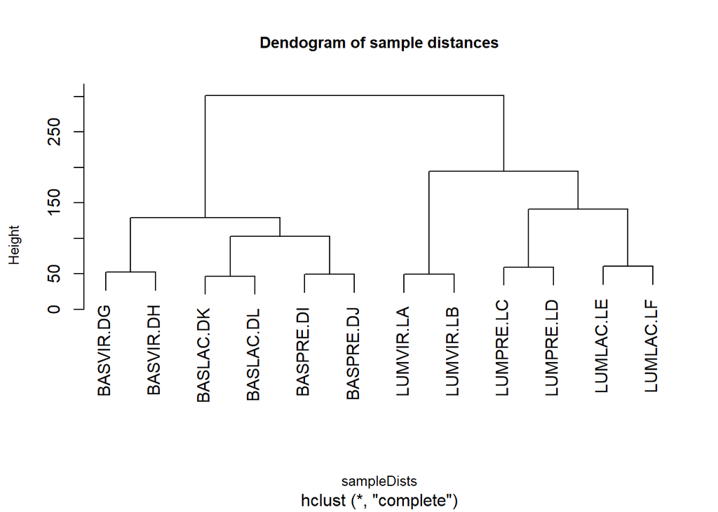

```r
plot(hclust(sampleDists),labels = colnames(logcounts_norm),main = "Dendogram of sample distances", cex.lab=0.8, cex.main=0.9)
```

Como puede verse las muestras tienden a agruparse, por grupo, luminal o basal, dentro de éste por estado y finalmente por réplica.

## 6.4 Visualización en dimensión reducida

Un enfoque complementario para determinar las principales fuentes de variabilidad en los datos es la visualización en dimensión reducida, ya sea de los datos o de la matriz de similaridades.

Para la primera representación es habitual basarse en el resultado de un análisis de componentes principales (PCA) que representan las direcciones a lo largo de las cuales la variación en la matriz de datos es máxima, con la ventaja de que dichas direcciones son ortogonales (es decir independientes) y que explica cada una más información que la siguiente, por lo que con unas pocas dimensiones se suele poder explicar un alto porcentaje de la variabilidad.

De forma análoga, el escalamiento multidimensional permite llevar a cabo una transformación similar a la del PCA, pero con la matriz de distancias, lo que proporciona una representación en dimensión reducida que describe con relativa fidelidad las diferencias y similaridades entre muestras.

Para esta segunda representación utilizaremos la función `plotMDS` del paquete `limma`.

```r
sampleinfo$Status <- factor (sampleinfo$Status)
col.status <- c("blue","red","dark green")[sampleinfo$Status]
data.frame(sampleinfo$Status,col.status)
```

```
##    sampleinfo.Status col.status
## 1             virgin dark green
## 2             virgin dark green
## 3           pregnant        red
## 4           pregnant        red
## 5            lactate       blue
## 6            lactate       blue
## 7             virgin dark green
## 8             virgin dark green
## 9           pregnant        red
## 10          pregnant        red
## 11           lactate       blue
## 12           lactate       blue
```

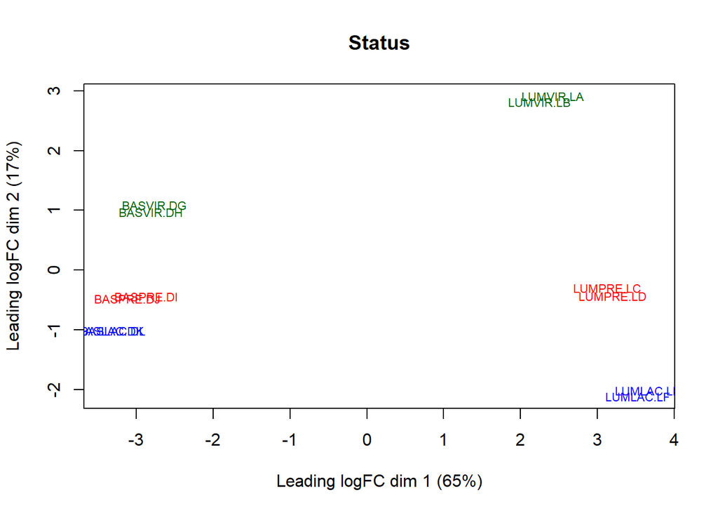

```r
limma::plotMDS(logcounts_norm,col=col.status, main="Status", cex=0.7)
```

Como puede verse, el gráfico muestra la misma agrupación “natural” que el cluster jerárquico es decir que los grupos parecen estar bien definidos.

# 7 Análisis de expresión diferencial con limma-voom

Una vez normalizados los datos, y tras comprobar su calidad, podemos proceder a seleccionar genes diferencialmente expresados.

Desde el inicio del análisis de datos de RNA-seq se ha puesto énfasis en la diferencia entre datos de microarrays, que son variables continuas que proporcionan una medida indirecta de la expresión génica, frente a los datos de RNA-seq que son contajes de secuencias por lo que miden directamente la expresión.

Siguiendo una cierta ortodoxia estadística, los primeros se suelen modelizar y analizar con (extensiones) del *modelo lineal general*, por ejemplo usando el paquete `limma` y los segundos con (extensiones) de *modelos lineales generalizados* propios de datos de contaje, usando por ejemplo el paquete `DESEQ2` o `edgeR`. Recientemente se introdujo una solución intermedia para datos de contaje consistente en aplicarles una transformación que los hace continuos permitiendo analizarlos con el paquete `limma` o su extensión `Glimma`.

El paquete `limma` (Ritchie et al. 2015) ofrece la función `voom`, que transforma los recuentos de “reads” en `logCMM` teniendo en cuenta la relación media-varianza en los datos (Charity W. Law et al. 2014). Una vez transformados los datos (`vooming`), los usuarios pueden aplicar un modelo lineal a los datos transformados en voom para probar genes expresados diferencialmente, con la suposición de que los datos subyacentes se distribuyen normalmente.

La ventaja principal de esta aproximación es que permite trabajar con toda la flexibilidad de los modelos lineales para representar diseños experimentales, y, en muchos casos , aprovechar la experiencia previa del usuario en el manejo de limma.

## 7.1 Creación de la matriz de diseño y de contrastes

Supongamos que estamos interesados en genes que se ven afectados por el embarazo y la lactancia en individuos basales o luminales. Utilizando las variable “CellType” y “Status” que combina ambos factores podemos definir la matriz del diseño y, sobre ésta, los contrastes que nos interesan.

```r
library(limma)
group <- paste(sampleinfo$CellType, sampleinfo$Status,  sep="." )
design  <-  model.matrix(~0+group)
colnames(design) <- gsub("group", "", colnames(design))
rownames(design) <- sampleinfo$SampleName
design
```

```
##         basal.lactate basal.pregnant basal.virgin luminal.lactate
## MCL1.DG             0              0            1               0
## MCL1.DH             0              0            1               0
## MCL1.DI             0              1            0               0
## MCL1.DJ             0              1            0               0
## MCL1.DK             1              0            0               0
## MCL1.DL             1              0            0               0
## MCL1.LA             0              0            0               0
## MCL1.LB             0              0            0               0
## MCL1.LC             0              0            0               0
## MCL1.LD             0              0            0               0
## MCL1.LE             0              0            0               1
## MCL1.LF             0              0            0               1
##         luminal.pregnant luminal.virgin
## MCL1.DG                0              0
## MCL1.DH                0              0
## MCL1.DI                0              0
## MCL1.DJ                0              0
## MCL1.DK                0              0
## MCL1.DL                0              0
## MCL1.LA                0              1
## MCL1.LB                0              1
## MCL1.LC                1              0
## MCL1.LD                1              0
## MCL1.LE                0              0
## MCL1.LF                0              0
## attr(,"assign")
## [1] 1 1 1 1 1 1
## attr(,"contrasts")
## attr(,"contrasts")$group
## [1] "contr.treatment"
```

Dado que estamos interesados en las diferencias entre los grupos, necesitamos especificar qué comparaciones queremos llevar a cabo. Las comparaciones de interés se puede especificar utilizando la función `makeContrasts`. La matriz de contraste indica qué columnas de la matriz `design` vamos a comparar.

```r
cont.matrix <- makeContrasts(B.PregVsLac=basal.pregnant - basal.lactate,
                             L.PregVsLac=luminal.pregnant - luminal.lactate, levels=design)
cont.matrix
```

```
##                   Contrasts
## Levels             B.PregVsLac L.PregVsLac
##   basal.lactate             -1           0
##   basal.pregnant             1           0
##   basal.virgin               0           0
##   luminal.lactate            0          -1
##   luminal.pregnant           0           1
##   luminal.virgin             0           0
```

## 7.2 Transformación de los datos

Tal como se ha indicado la transformación `voom` creará un nuevo objeto con campos equivalentes a los del DGELIST pero que puede ser analizado con limma.

```r
voomObj <- voom(dgeObj_norm, design)
voomObj
```

```
## An object of class "EList"
## $targets
##           group lib.size norm.factors
## BASVIR.DG     1 28718360     1.236899
## BASVIR.DH     1 26425396     1.213949
## BASPRE.DI     1 27116624     1.125564
## BASPRE.DJ     1 24238743     1.069826
## BASLAC.DK     1 22295130     1.035921
## 7 more rows ...
##
## $E
##        BASVIR.DG BASVIR.DH BASPRE.DI BASPRE.DJ BASLAC.DK BASLAC.DL  LUMVIR.LA
## 497097  3.932532  3.507368  1.272317  3.292541 3.9909851  3.724252 -5.8019424
## 20671   1.890808  2.787899  1.605217  2.121856 0.9642868  1.923156 -0.7575483
## 27395   3.429894  3.149591  3.637638  3.631978 3.7037376  3.636318  4.3286281
## 18777   4.505933  4.285975  5.128398  5.270351 5.3801014  5.185279  4.8889286
## 21399   5.804007  5.822559  5.988345  5.764344 5.7006304  5.615502  5.5801412
##         LUMVIR.LB  LUMPRE.LC LUMPRE.LD LUMLAC.LE  LUMLAC.LF
## 497097 -5.8887821 -5.4816421 -5.343143 -4.709206 -4.7226146
## 20671  -0.2163568 -0.2721888 -1.255680 -1.901851 -0.3302972
## 27395   3.9707527  4.4535229  4.016606  4.555237  4.6973455
## 18777   4.8635986  4.9031416  4.993363  5.379583  5.4610208
## 21399   5.4087074  5.5797290  5.512504  5.280898  5.2446116
## 15799 more rows ...
##
## $weights
##          [,1]     [,2]     [,3]     [,4]     [,5]     [,6]       [,7]
## [1,] 42.85032 40.59638 19.78119 18.11020 38.62541 37.98661  0.7907909
## [2,] 21.34610 19.99539 15.74020 14.40027 10.70068 10.49511  4.5401043
## [3,] 35.05544 33.04583 39.72941 36.82081 35.31518 34.70612 50.4586968
## [4,] 56.26175 53.86441 69.16366 66.65108 66.03797 65.46069 64.6692219
## [5,] 76.92857 75.98600 76.79528 75.45282 71.62644 71.16558 73.5980084
##            [,8]       [,9]      [,10]      [,11]      [,12]
## [1,]  0.7907909  0.7907909  0.7907909  0.7907909  0.7907909
## [2,]  4.7399033  3.4277768  3.2224692  2.1314506  2.1428929
## [3,] 52.1833006 45.7806579 43.1302387 38.6112610 38.8559918
## [4,] 66.0984998 60.0161723 57.3174922 54.0693981 54.3410792
## [5,] 74.5613544 70.1642210 68.1238307 50.8570652 51.1210163
## 15799 more rows ...
##
## $design
##         basal.lactate basal.pregnant basal.virgin luminal.lactate
## MCL1.DG             0              0            1               0
## MCL1.DH             0              0            1               0
## MCL1.DI             0              1            0               0
## MCL1.DJ             0              1            0               0
## MCL1.DK             1              0            0               0
##         luminal.pregnant luminal.virgin
## MCL1.DG                0              0
## MCL1.DH                0              0
## MCL1.DI                0              0
## MCL1.DJ                0              0
## MCL1.DK                0              0
## 7 more rows ...
```

## 7.3 Selección de genes diferencialmente expresados

Como en el caso de los microarrays el objeto `voomObj` y las matrices de diseño y contrastes se utilizaran para ajustar un modelo y, a continuación realizar las comparaciones especificadas sobre el modelo ajustado. El proceso finaliza con la regularización del estimador del error usando la función `eBayes`.

```r
# Fit the linear model
fit <- lmFit(voomObj)
fit.cont <- contrasts.fit(fit, cont.matrix)
fit.cont <- eBayes(fit.cont)
```

## 7.4 Top tables

Los resultados de un análisis de expresión diferencial se pueden extraer con la función `topTable`. Esta función genera una tabla de resultados cuyas columnas contienen información acerca de los genes y la diferencia entre los grupos comparados. Concretamente:

- `logFCcolumn` da el cambio en escala logarítmica en la expresión de un gen entre los grupos comparados.
- `AveExpr` da el nivel promedio de expresión log2 para ese gen en todas las muestras del experimento.
- `t` es el valor del estadístico “t-moderada”, similar al estadístico del test “t” de student, pero con un estimador mejorado de la varianza en su denominador.
- `P.Value` es el valor p asociado a la comparación realizada.
- `Adj. P.Value` es el valor p ajustado para comparaciones múltiples . La forma más popular de ajuste es “BH”, que es el método de Benjamini y Hochberg para controlar la tasa de falsos positivos (FDR).
- `B` es el logaritmo de la probabilidad posterior de que el gen se exprese diferencialmente frente a que no lo haga. Básicamente, cuanto mayor es B, más plausible resulta que el gen se encuentre diferencialmente expresado.

```r
toptab_B.PregVsLac <- topTable(fit.cont,coef=1,sort.by="p", number=nrow(fit.cont))
head(toptab_B.PregVsLac)
```

```
##            logFC  AveExpr         t      P.Value   adj.P.Val        B
## 24117   1.819943 2.975545  20.10780 1.063770e-10 1.01624e-06 14.96977
## 381290 -2.143885 3.944066 -19.07495 1.982934e-10 1.01624e-06 14.39556
## 78896   2.807548 3.036519  18.54773 2.758828e-10 1.01624e-06 14.07416
## 226101 -2.329744 6.223525 -18.26861 3.297667e-10 1.01624e-06 13.85802
## 16012  -2.896115 1.978449 -18.21525 3.413066e-10 1.01624e-06 13.46984
## 231830  2.253400 4.760597  18.02627 3.858161e-10 1.01624e-06 13.67600
```

```r
toptab_L.PregVsLac <- topTable(fit.cont,coef=2,sort.by="p", number=nrow(fit.cont))
head(toptab_L.PregVsLac)
```

```
##            logFC  AveExpr         t      P.Value    adj.P.Val        B
## 12992  -8.603611 3.562950 -46.84744 4.172002e-15 6.593433e-11 23.84700
## 13358  -4.124175 5.779699 -34.76897 1.526326e-13 1.206103e-09 21.38712
## 20531  -4.177812 4.278629 -31.24354 5.524752e-13 2.910439e-09 20.23287
## 11941  -7.386986 1.282143 -30.01476 8.946195e-13 3.534642e-09 18.54201
## 230810 -3.203118 2.695811 -29.31342 1.188209e-12 3.654867e-09 19.42820
## 100705 -4.314320 4.440914 -28.93689 1.387573e-12 3.654867e-09 19.30790
```

Para visualizar los resultados de cada comparación podemos usar un `volcanoPlot`:

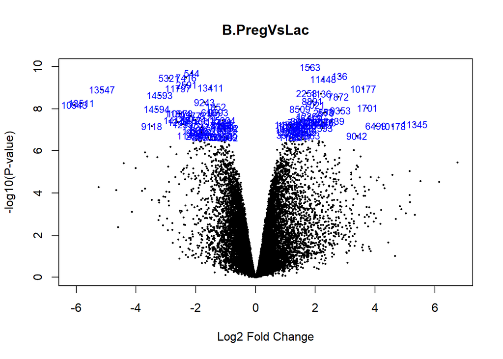

```r
volcanoplot(fit.cont,coef=1,highlight=100,names=fit.cont$genes$SYMBOL, main="B.PregVsLac")
```

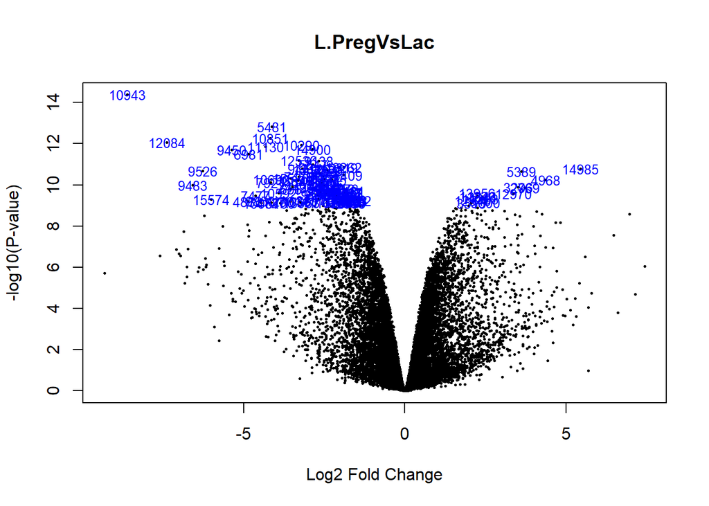

```r
volcanoplot(fit.cont,coef=2,highlight=100,names=fit.cont$genes$SYMBOL, main="L.PregVsLac")
```

Los resultados pueden guardarse en archivos de texto o enviarse a tablas HTML interactivas (esta opción ocupa mucho espacio y memoria por lo que aquí se omite).

```r
write.csv(toptab_B.PregVsLac, "toptab_B.PregVsLac.csv")
write.csv(toptab_B.PregVsLac, "toptab_L.PregVsLac.csv")
```

## 7.5 Comparaciones múltiples y visualización de los resultados.

Cuando se llevan a cabo varias comparaciones es interesante compararlas entre ellas para saber cuantos genes diferencialmente expresados (GDE) se han seleccionado en cada una. La función de `limma` `decideTests` generar un resumen rápido de dichos genes a partir del umbral definido por un p-valor ajustado (retendrá los valores cuyo p-valor sea inferior al punto de corte) y un “log-Fold-Change” (retendrá los valores cuyo log-fold-change sea superior al punto de corte) proporcionados por el usuario.

```r
summa.fit <- decideTests(fit.cont, p.value = 0.05, lfc = 2)
summary(summa.fit)
```

```
##        B.PregVsLac L.PregVsLac
## Down           101         607
## NotSig       15409       14710
## Up             294         487
```

Un diagrama de Venn nos mostrará no tan sólo el numero seleccionado en cada caso, sino también cuantos hay en común entre comparaciones.

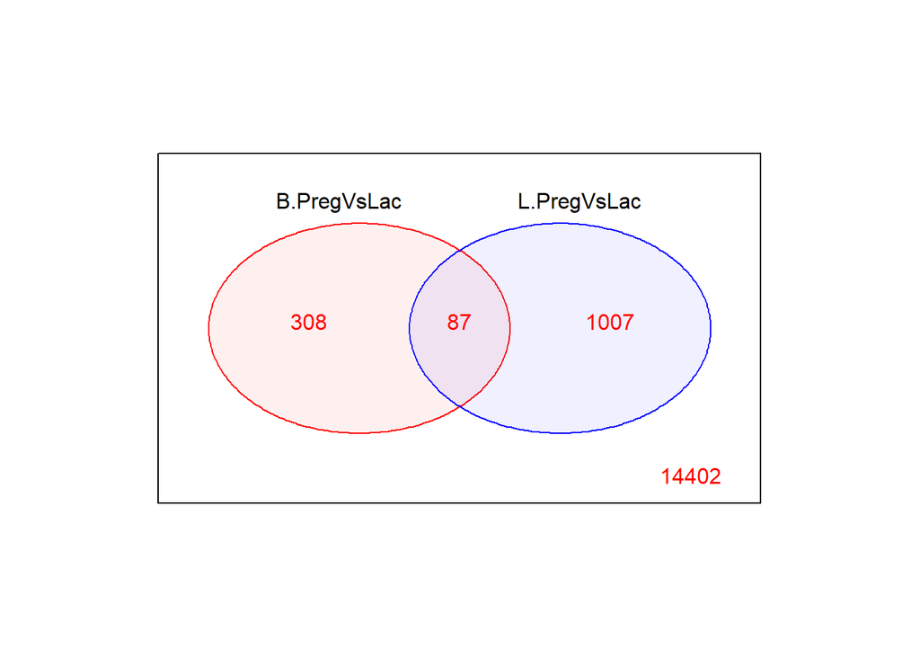

```r
vc<- vennCounts(summa.fit)
vennDiagram(vc, include=c("up", "down"),
    counts.col=c("red", "blue"),
    circle.col = c("red", "blue", "green3"), cex=c(1,1,1))
```

### 7.5.1 Visualización de perfiles de expresión

Los perfiles de expresión obtenidos para los genes expresados diferencialmente superiores se pueden trazar en un mapa de calor, con genes (filas) y muestras (columnas) agrupados por similitud.

```r
library("pheatmap")
topGenesBas <- rownames(subset(toptab_B.PregVsLac, (abs(logFC)> 2) & (adj.P.Val < 0.05)))
length(topGenesBas)
```

```
## [1] 395
```

```r
topGenesLum <- rownames(subset(toptab_L.PregVsLac, (abs(logFC)> 2) & (adj.P.Val < 0.05)))
length(topGenesLum)
```

```
## [1] 1094
```

```r
topGenes <- union(topGenesBas, topGenesLum)
length(topGenes)
```

```
## [1] 1402
```

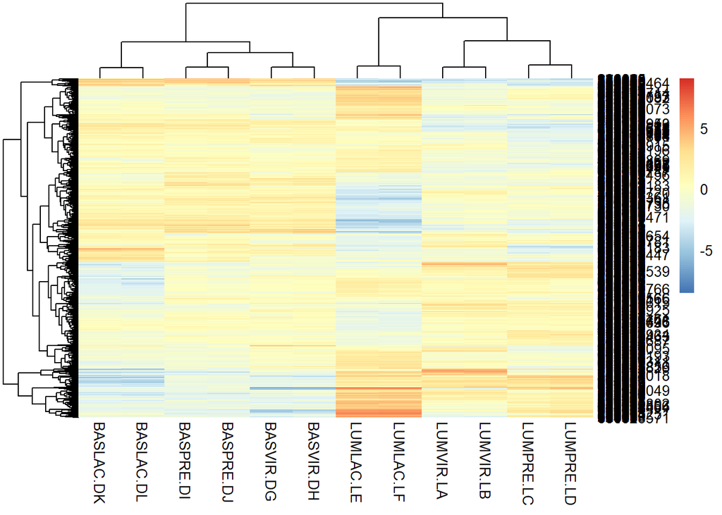

```r
mat  <- logcounts_norm[topGenes, sampleinfo$ShortName]
mat  <- mat - rowMeans(mat)
library(pheatmap)
pheatmap(mat)
```

# 8 Análisis de significación biológica

Una vez seleccionados los genes diferencialmente expresados podemos proceder al análisis de las listas de genes obtenidas.

Para simplificar el ejemplo nos centraremos en la lista resultante de la comparación “B.PregVsLac” que compara los estados “pregnant” y “lactate” en el grupo “Basal”. El análisis de otras listas se realizaría de forma análoga.

Cambiamos de nombre la tabla resultante del análisis con lo que resultaría más sencillo adaptar los análisis para otras tablas.

```r
topTab<- toptab_B.PregVsLac
head(topTab)
```

```
##            logFC  AveExpr         t      P.Value   adj.P.Val        B
## 24117   1.819943 2.975545  20.10780 1.063770e-10 1.01624e-06 14.96977
## 381290 -2.143885 3.944066 -19.07495 1.982934e-10 1.01624e-06 14.39556
## 78896   2.807548 3.036519  18.54773 2.758828e-10 1.01624e-06 14.07416
## 226101 -2.329744 6.223525 -18.26861 3.297667e-10 1.01624e-06 13.85802
## 16012  -2.896115 1.978449 -18.21525 3.413066e-10 1.01624e-06 13.46984
## 231830  2.253400 4.760597  18.02627 3.858161e-10 1.01624e-06 13.67600
```

Consultando el manual de limma se confirma que las filas de dicha tabla son los identificadores `Entrez` de los genes analizados. Estos identificadores son los habitualmente utilizados por los programas de análisis de significación biológica por lo que obtendremos los identificadores de:

- la lista de genes analizados y
- la lista de genes seleccionados.

Nos centraremos únicamente en la lista de genes “up-regulados” es decir diferencialmente expresados con un logFC mayor que dos (más expresados en “pregnant” que en “lactate”).

```r
allEntrezs <- rownames(topTab)
selectedEntrezsUP <- rownames(subset(topTab, (logFC> 2) & (adj.P.Val < 0.05)))
length(allEntrezs); length(selectedEntrezsUP)
```

```
## [1] 15804
```

```
## [1] 294
```

Para el análisis de enriquecimiento utilizaremos la función `enrichGO` del paquete `clusterProfiler muy parecida a las de otros paquetes como`GOstats`.

```r
library(clusterProfiler)
library(org.Mm.eg.db)
ego <- enrichGO(gene = selectedEntrezsUP,
                universe = allEntrezs,
                keyType = "ENTREZID",
                OrgDb = org.Mm.eg.db,
                ont = "BP",
                pAdjustMethod = "BH",
                qvalueCutoff = 0.05,
                readable = TRUE)
```

El objeto resultante almacena las categorías GO enriquecidas, los genes anotados en ellas y los valores de los estadísticos que llevan a afirmar que dichas categorías se encuentran significativamente sobre-representadas como resultado de un test de enriquecimiento.

```r
head(ego)
```

```
##                    ID                          Description GeneRatio   BgRatio
## GO:0000070 GO:0000070 mitotic sister chromatid segregation    25/283 174/14565
## GO:0140014 GO:0140014             mitotic nuclear division    27/283 249/14565
## GO:0000819 GO:0000819         sister chromatid segregation    25/283 212/14565
## GO:0007059 GO:0007059               chromosome segregation    33/283 379/14565
## GO:0000280 GO:0000280                     nuclear division    31/283 376/14565
## GO:0098813 GO:0098813       nuclear chromosome segregation    26/283 280/14565
##            RichFactor FoldEnrichment    zScore       pvalue     p.adjust
## GO:0000070 0.14367816       7.394602 11.944878 4.636805e-15 1.605726e-11
## GO:0140014 0.10843373       5.580697 10.262649 4.067478e-13 4.077843e-10
## GO:0000819 0.11792453       6.069155 10.465769 4.699001e-13 4.077843e-10
## GO:0007059 0.08707124       4.481246  9.666369 4.710186e-13 4.077843e-10
## GO:0000280 0.08244681       4.243243  8.968846 1.047818e-11 7.257191e-09
## GO:0098813 0.09285714       4.779026  8.987891 3.913008e-11 2.258458e-08
##                  qvalue
## GO:0000070 1.341257e-11
## GO:0140014 3.406208e-10
## GO:0000819 3.406208e-10
## GO:0007059 3.406208e-10
## GO:0000280 6.061906e-09
## GO:0098813 1.886482e-08
##                                                                                                                                                                                                          geneID
## GO:0000070                                                  Kif23/Nuf2/Cit/Kif11/Kntc1/Tpx2/Ncapg/Cdk1/Kifc1/Racgap1/Aurkb/Bub1/Nusap1/Knl1/Cdca5/Kif22/Plk1/Cdca8/Spc24/Ska1/Bub1b/Ccnb1-ps/Kif18b/Ccnb1/Ube2c
## GO:0140014                                         Kif23/Nuf2/Cit/Kif11/Kntc1/Tpx2/Ncapg/Cdk1/Kifc1/Racgap1/Aurkb/Bub1/Nusap1/Knl1/Cdca5/Kif22/Plk1/Tnf/Cdca8/Spc24/Ska1/Bub1b/Ccnb1-ps/Kif18b/Ccnb1/Edn1/Ube2c
## GO:0000819                                                  Kif23/Nuf2/Cit/Kif11/Kntc1/Tpx2/Ncapg/Cdk1/Kifc1/Racgap1/Aurkb/Bub1/Nusap1/Knl1/Cdca5/Kif22/Plk1/Cdca8/Spc24/Ska1/Bub1b/Ccnb1-ps/Kif18b/Ccnb1/Ube2c
## GO:0007059 Diaph3/Kif23/Nuf2/Cit/Kif11/Kntc1/Tpx2/Ncapg/Cdk1/Kifc1/Racgap1/Cenph/Aurkb/Cenpf/Bub1/Nusap1/Knl1/Cdca5/Kif22/Plk1/Cenpm/Cdca8/Spc24/Ska1/Bub1b/Ccnb1-ps/Esco2/Dlgap5/Kif18b/Ccnb1/Oip5/Ube2c/Brca1
## GO:0000280                  Lif/Kif23/Nuf2/Cit/Kif11/Kntc1/Tpx2/Fanca/Ncapg/Cdk1/Kifc1/Racgap1/Rad51/Aurkb/Bub1/Nusap1/Knl1/Cdca5/Kif22/Plk1/Tnf/Cdca8/Spc24/Ska1/Bub1b/Ccnb1-ps/Kif18b/Ccnb1/Edn1/Fignl1/Ube2c
## GO:0098813                                            Kif23/Nuf2/Cit/Kif11/Kntc1/Tpx2/Ncapg/Cdk1/Kifc1/Racgap1/Aurkb/Cenpf/Bub1/Nusap1/Knl1/Cdca5/Kif22/Plk1/Cdca8/Spc24/Ska1/Bub1b/Ccnb1-ps/Kif18b/Ccnb1/Ube2c
##            Count
## GO:0000070    25
## GO:0140014    27
## GO:0000819    25
## GO:0007059    33
## GO:0000280    31
## GO:0098813    26
```

```r
ego_results <- data.frame(ego)
write.csv(ego_results, "clusterProfiler_ORAresults_UpGO.csv")
```

## 8.1 Visualización de los resultados del análisis de enriquecimiento

Uno de los aspectos interesantes del paquete `clusterProfiler` es que permite visualizar los resultados mediante algunos gráficos creados específicamente para tal fin.

Este gráfico compara visualmente las categorías enriquecidas (de más a menos enriquecidas) visualizando simultáneamente cuan enriquecidas estan y el p-valor del test de enriquecimiento.

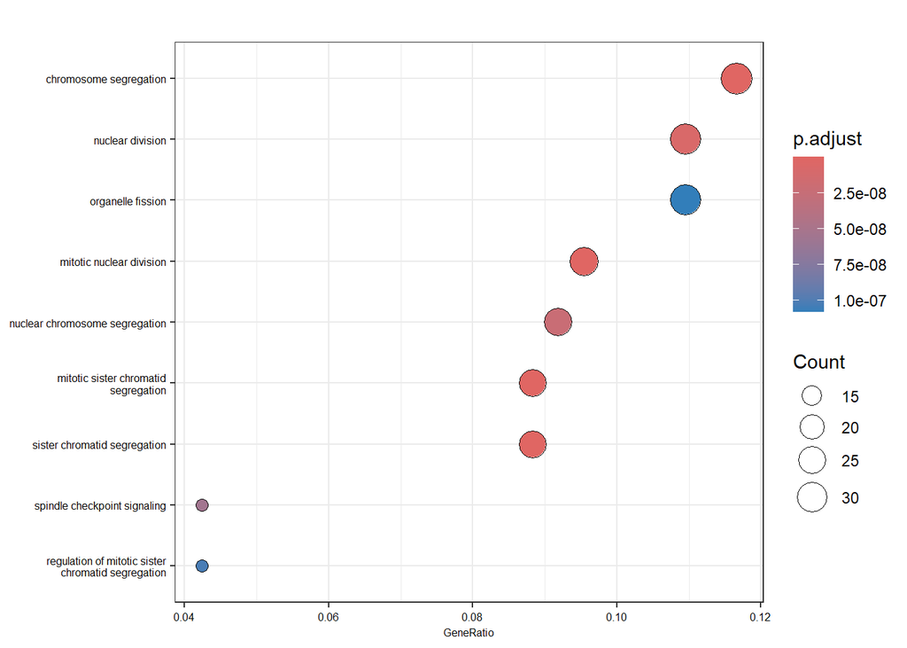

```r
dotplot(ego, showCategory=9, font.size=6)
```

**Visualización jerárquica de los términos GO**

Este gráfico permite visualizar los términos seleccionados dentro del sub-grafo de la GO que los contiene. Esto nos, permite por ejemplo, hacernos una idea de si estan muy dispersos, o no, en la jerarquía y de si se trata de términos muy generales o más específicos.

```r
# En fech 2024-12-07 Esta funcion falla con R 4.4, por lo que se puede omitir su uso
goplot(ego)
```

[output not shown]

**Gene network para los términos seleccionados**

De forma parecida una red de genes nos permite visualizar la asociación entre los genes y las categorías seleccionadas en las que éstos genes estan anotados.

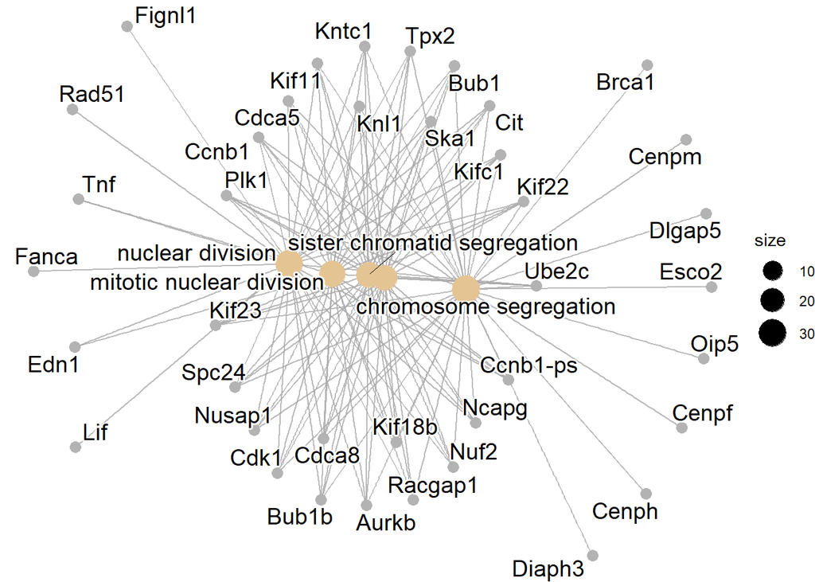

```r
cnetplot(ego, font.size=5)
```

**Enrichment Map**

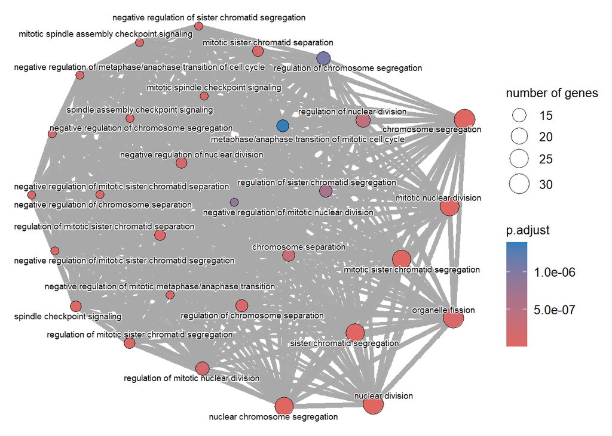

```r
library(enrichplot)
ego_sim <- pairwise_termsim(ego)
emapplot(ego_sim, cex_label_category=0.5)
```